# Reproducible Research Peer Assessment 1

## Loading and preprocessing the data

Read **activity.csv** file into variable *activity*.  
Convert the date column into a YYYY-MM-DD format.

```r
activity <- read.csv("activity.csv", sep=",", header=TRUE, stringsAsFactors=FALSE, na.strings=NA)
activity$date <- as.Date(activity$date, format="%Y-%m-%d")
head(activity); tail(activity)
```

```
##   steps       date interval
## 1    NA 2012-10-01        0
## 2    NA 2012-10-01        5
## 3    NA 2012-10-01       10
## 4    NA 2012-10-01       15
## 5    NA 2012-10-01       20
## 6    NA 2012-10-01       25
```

```
##       steps       date interval
## 17563    NA 2012-11-30     2330
## 17564    NA 2012-11-30     2335
## 17565    NA 2012-11-30     2340
## 17566    NA 2012-11-30     2345
## 17567    NA 2012-11-30     2350
## 17568    NA 2012-11-30     2355
```

Load libraries *dplyr*, *ggplot2*

```r
library(dplyr)
```

```r
library(ggplot2)
```

## Mean total number of steps taken per day

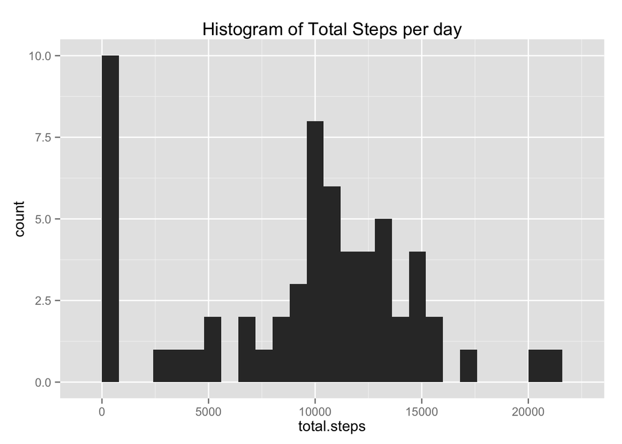

```r
steps.day <- activity %>%
  group_by(date) %>%
  summarise(sum(steps, na.rm=TRUE))
colnames(steps.day) <- c("date", "total.steps")
total.steps.plot <- ggplot(steps.day, aes(x=total.steps)) +
  geom_histogram(binwidth=800) +
  ggtitle("Histogram of Total Steps per day")
total.steps.plot
```

Mean and median steps taken excluding NA values

```r
steps.summary <- as.data.frame(cbind(mean(steps.day$total.steps), median(steps.day$total.steps)))
colnames(steps.summary) <- c("mean", "median")
head(steps.summary); tail(steps.summary)
```

```
##      mean median
## 1 9354.23  10395
```

```
##      mean median
## 1 9354.23  10395
```

## Average daily activity pattern

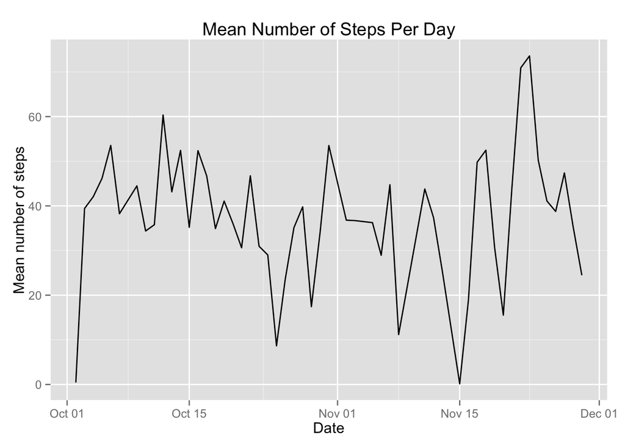

```r
mean.steps <- activity %>%
  group_by(date) %>%
  summarise(mean(steps, na.rm=TRUE))
mean.steps <- subset(mean.steps[which(complete.cases(mean.steps)==TRUE),])
colnames(mean.steps) <- c("date", "mean.steps")
meansteps.plot <- ggplot(mean.steps, aes(x=date, y=mean.steps)) +
  geom_line() +
  ggtitle("Mean Number of Steps Per Day") + xlab("Date") + ylab("Mean number of steps")
meansteps.plot
```

```r
steps.int <- activity %>%
  group_by(interval) %>%
  summarise(mean(steps, na.rm=TRUE))
colnames(steps.int) <- c("interval", "mean.steps")
```

5-min interval with the highest number of steps

```r
steps.int[which(steps.int$mean.steps==max(steps.int$mean.steps)),]
```

```
## Source: local data frame [1 x 2]
##
##   interval mean.steps
## 1      835   206.1698
```

## Imputing missing values

Remove NA values from the steps column by using an intermediate variable *act.na* by:  
1. subsetting *act.na* from the *activity* dataset containing only NA values in the steps column.  
2. using the *left_join* function, merge the *act.na* and *steps.int* datasets  
3. impute the missing (NA) values by selecting the mean steps at each 5-min interval from the mean.steps column.  
4. *anti_join* dataset *act.na* to the main *activity* dataset to eliminate the copies of rows with missing values (NA) in the steps column into a new variable *act.imp*.  
5. rbind *act.na* and *act.imp* into *act.imp* to obtain a complete dataset with imputed values

```r
act.na <- filter(activity, is.na(steps)==T) #1
act.na <- left_join(act.na, steps.int, by="interval") #2
act.na <- transmute(act.na, steps = mean.steps, date=date, interval=interval) #3
act.imp <- anti_join(activity, act.na, by=c("date", "interval")) #4
act.imp <- rbind(act.na, act.imp) %>% #5
  arrange(date, interval)
```

### Number of missing values in dataset

```r
length(act.na$steps)
```

```
## [1] 2304
```

### Histogram of adjusted total steps each day

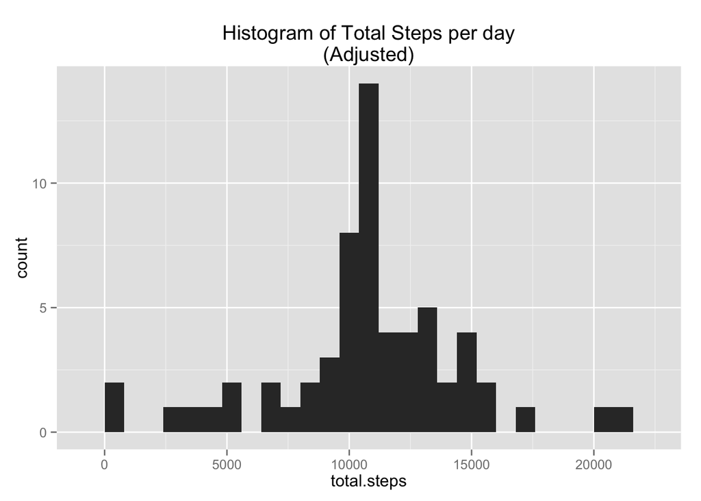

```r
steps.day.imp <- act.imp %>%
  group_by(date) %>%
  summarise(sum(steps, na.rm=TRUE))
colnames(steps.day.imp) <- c("date", "total.steps")
total.steps.plot.imp <- ggplot(steps.day.imp, aes(x=total.steps)) +
  geom_histogram(binwidth=800) +
  ggtitle("Histogram of Total Steps per day\n(Adjusted)")
total.steps.plot.imp
```

### Adjusted mean and median total steps each day

```r
steps.summary.imp <- as.data.frame(cbind(mean(steps.day.imp$total.steps), median(steps.day.imp$total.steps)))
colnames(steps.summary.imp) <- c("mean", "median")
steps.summary.imp
```

```
##       mean   median
## 1 10766.19 10766.19
```

## Differences in activity patterns between weekdays and weekends

Create a new *day.type* column in the *act.imp* (activity with imputed values) dataset indicating either weekend or weekday

```r
act.imp <- mutate(act.imp, date, day.type=ifelse(weekdays(act.imp$date)%in%c("Saturday", "Sunday"), "Weekend", "Weekday"))
act.imp$day.type <- as.factor(act.imp$day.type)
```

```r
daytype.comp <- act.imp %>%
  group_by(interval, day.type) %>%
  summarise(mean.steps=mean(steps))
head(daytype.comp); tail(daytype.comp)
```

```
## Source: local data frame [6 x 3]
## Groups: interval
##
##   interval day.type mean.steps
## 1        0  Weekday 2.25115304
## 2        0  Weekend 0.21462264
## 3        5  Weekday 0.44528302
## 4        5  Weekend 0.04245283
## 5       10  Weekday 0.17316562
## 6       10  Weekend 0.01650943
```

```
## Source: local data frame [6 x 3]
## Groups: interval
##
##   interval day.type mean.steps
## 1     2345  Weekday 0.26331237
## 2     2345  Weekend 1.70518868
## 3     2350  Weekday 0.29685535
## 4     2350  Weekend 0.02830189
## 5     2355  Weekday 1.41006289
## 6     2355  Weekend 0.13443396
```

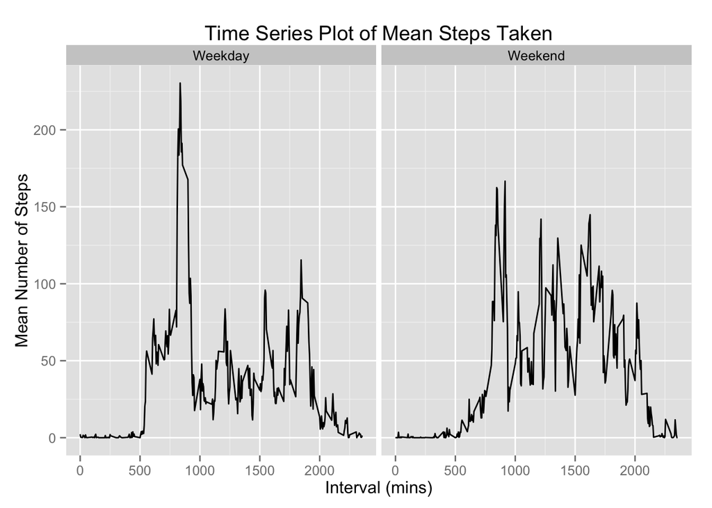

```r
daytype.plot <- ggplot(daytype.comp, aes(x=interval, y=mean.steps)) +
  geom_line() + facet_grid(. ~ day.type) +
  ggtitle("Time Series Plot of Mean Steps Taken") +
  xlab("Interval (mins)") + ylab("Mean Number of Steps")
daytype.plot
```